# Pregnacy specific serology to detect geographical patterns of malaria transmission in Mozambique

Ana Fonseca

Junho 01, 2017

# INTRODUCTION

In recent years, there has been a decline in malaria transmission in many regions, leading to optimism that malaria elimination might be achieved in numerous countries. As transmission declines, surveillance becomes increasingly important and metrics used to estimate malaria exposure in a community need to account for dynamic changes over space and time essential to guide strategic planning, implementation and evaluation of interventions (WHO 2016). Traditionally, surveillance has been typically reliant on case reporting by health services, entomological estimates and parasitemia point prevalence. However, these metrics are difficult to apply, costly and poorly informative once transmission becomes low and the sample sizes required make them unfeasible for the purposes of routine surveillance (Stewart et al. 2009). In contrast, serology has recently become more attractive as an epidemiologic tool (Drakeley and Cook 2009; Corran et al. 2007) and discovery of new antigenic targets is a research priority on the malaria elimination agenda (MalERA recent) enhanced by the improved technology for high-throughput screening (Kerkhof et al. 2015; Helb et al. 2015). Serology can target antenatal clinic populations since they are a convenient and easy-to-access group for real-time surveillance of infectious diseases (i.e., HIV). Moreover pregnant women are more susceptible to malaria than non-pregnant adult individuals and the prevalence of infection was shown to strongly correlate with prevalence of infection detected in children (Eijk et al. 2015; Willilo et al. 2016). Malaria infected pregnant women develop antibodies against P. falciparum erythrocyte membrane protein VAR2CSA (350 kDa) that binds to Chondroitin Sulphate A (CSA) in the syncytiotrophoblasts (Salanti et al. 2003). Antibodies are developed in a parity depended manner (i.e., increase with exposure during successive pregnancies) (Ndam et al. 2006) and are affected by variables that influence the risk of exposure to P. falciparum such as season, proximity to the river (Mayor et al. 2013), use of IPTp (Serra-Casas et al. 2010) or insecticide-treated nets (ITN) (Aitken et al. 2012). Relatively low serological diversity of VAR2CSA (Hommel et al. 2010) and development of antibodies after single or very limited exposures to placental parasites (Mayor et al. 2011) supports the suitability of this antigen for the serological estimation of transmission.

Overall, these characteristics led us to hypothesize that detection of anti-VAR2CSA antibodies in pregnant women, who are easily accessible through antenatal care clinics, could constitute a useful field-deployable approach for malaria surveillance. For that, IgGs were measured in plasmas from Mozambican malaria-exposed pregnant women recruited between 2011 and 2012.

# METHODOLOGY

## Ethics statement

The study was approved by the Ethics Committees from the Hospital Clínic of Barcelona (Spain) and Mozambique. Written informed consent was obtained from all the participants.

## Study sites and population

The women included in this study were recruited during a clinical trial of intermittent preventive treatment during pregnancy (IPTp) between 2010-2012 (NCT00811421) in Mozambique (González, Desai, et al. 2014; González, Mombo-Ngoma, et al. 2014). All women included in the study received bed nets treated with long-lasting insecticide. Tissue samples from the maternal side of the placenta, as well as maternal peripheral-, placental-blood samples were collected at delivery. Blood was collected into EDTA vacutainers and centrifuged, with the plasma stored at −20ºC. More than one peripheral blood sample was collected during pregnancy from Mozambican women recruited during 2011-2012. 49 plasma samples were collected from pregnant women never exposed to P. falciparum, recruited at delivery at the Hospital Clinic in Barcelona during 2010. Clinical malaria episodes were treated according to national guidelines at the time of the study.

## Antigens

Recombinant protein used was VAR2CSA Duffy binding-like domain DBL5Ɛ, from 3D7 strain, merozoite surface protein-1, 19-kDa, (MSP119, from 3D7 strain), all produced at ICGEB (New Delhi, India). Two VAR2CSA synthetic peptides (p5 and p8) covering conserved and semi conserved regions of the protein. Peptides were synthetized by Gl Biochem (Xangai, China) and median purity was estimated as 79% (range: 71-91%) by HPLC and mass spectrometry.

## Immunological determinations

Antibodies were measured using the xMAP TM technology and the Luminex® 100/200™ System (Luminex® Corp., Austin, Texas). Two multiplex suspension array panels were constructed to quantify IgG responses against P. falciparum recombinant protein (DBL5Ɛ and MSP119), synthetic peptides (p5 and p8) from plasma samples following a modification of the protocol as previously described by us (Fonseca el all, submited). Presence or absence of antibodies was defined by finite mixture models (FMM) for pregnancy-specific antigens (VAR2CSA peptides and recombinant domains) (Corran et al. 2008) and by the mean plus 3 standard deviation (SD) of IgG response from Spanish pregnant women for the general malaria antigen (MSP119).

## Parasitological determinations

Thick and thin blood films, as well as placental biopsies, were read for Plasmodium species detection according to standard, quality-controlled procedures. Blood onto filter papers were tested for the presence of P. falciparum in duplicate by means of a real-time quantitative polymerase chain-reaction (qPCR) assay targeting 18S ribosomal RNA (rRNA). Past placental infection was defined by the presence of malaria pigment (i.e., hemozoin) without parasite detection on placental histologic examination, and chronic placental infection was defined by the presence of malaria pigment in combination with the detection of parasites. P. falciparum infection during pregnancy was defined if peripheral or placental blood samples were positive by microscopy or qPCR at any time-point of collection, if P. falciparum detected by hospital passive case detection (PCD), or if histology positive (active, chronic or past).

## Definitions and statistical analysis

Women were classified as primigravid (first pregnancy) and multigravid (at least one previous pregnancy). Age was categorized as younger than 20 years, 20 to 24 years, or 25 years of age or older 15.

Statistical analyses were performed with R.software (version 2.15.2).

# RESULTS

## 1.Samples description

Antibodies were measured in samples from 239 pregnant Mozambican women recruited during 2011 and 2012, 2 blood samples were collected during pregnancy (at the end of 2nd and 3rd trimesters) and 1 at delivery (total of 696 plasmas analyzed; exception of 21 women that only 1 plasma sample was collected during pregnancy plus delivery). The mean age was 24.5355649 and number of pregnacies was 2.9372385. 116 women had latitude and longitude data available in the moment of the study.

## 2. Serology to detect geographical patterns in Mozambique

The geographical distribution of malaria prevalences and seroprevalences among Mozambican pregnant women are shown in figures 3-8. The main P. falciparum hotspot was identified in the Maragra region by a concentration of pregnant women that had experienced at least one infection during pregnancy (dark orange color, figure 3) contrasting with a very low concentration of positives (cold-spot) in the center of Manhiça village (blue color, figure 3). Seroprevalence against p5 measured at delivery show a similar geographical distribution then the prevalence of infection detected during pregnancy (figure 4). Seroprevalence against p8, p5+8 and DBL5Ɛ were able to detect the same hot- and cold-spot in Maragra and Manhiça regions, respectively (figure 5-7). A higher percentage and more homogeneous geographical distribution of seropositives against MSP119 were reported when compared with VAR2CSA antigens (figure 8).

| age | parity |
| --- | --- |
| 24.53556 | 2.937238 |

Figure 1. Age distribution.

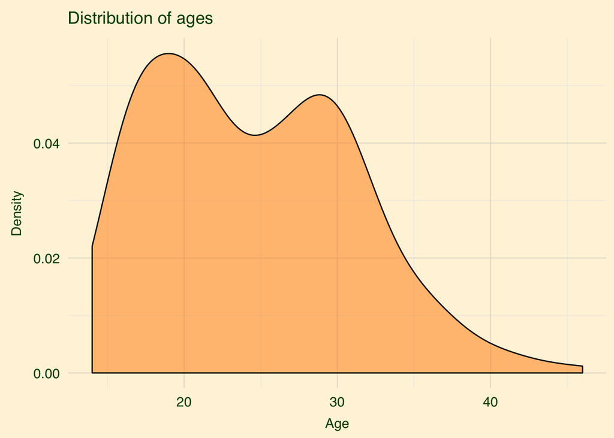

Figure 2. Number of pregnacies

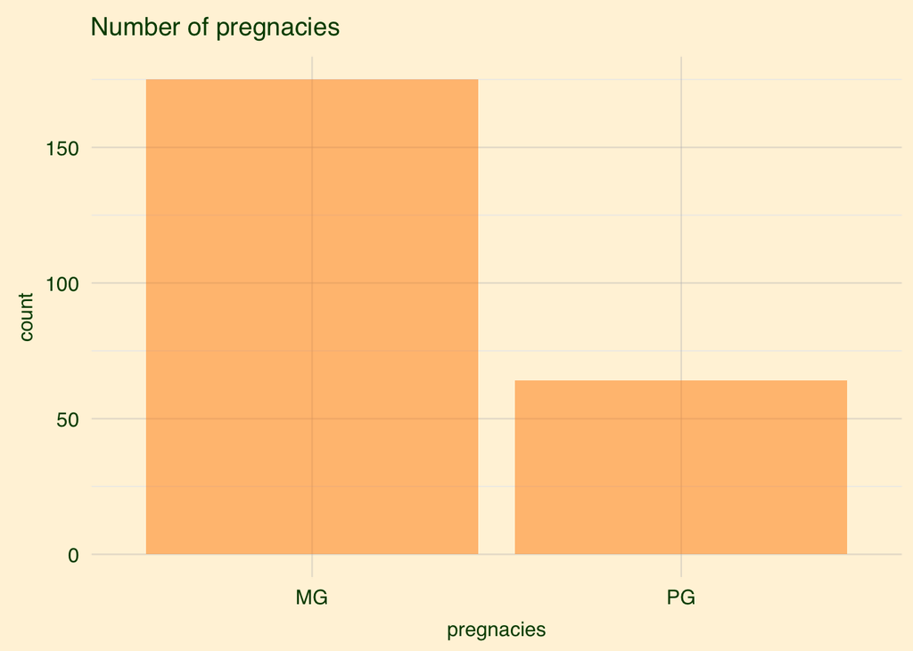

Figure 3. Map of infeccion during pregnacy.

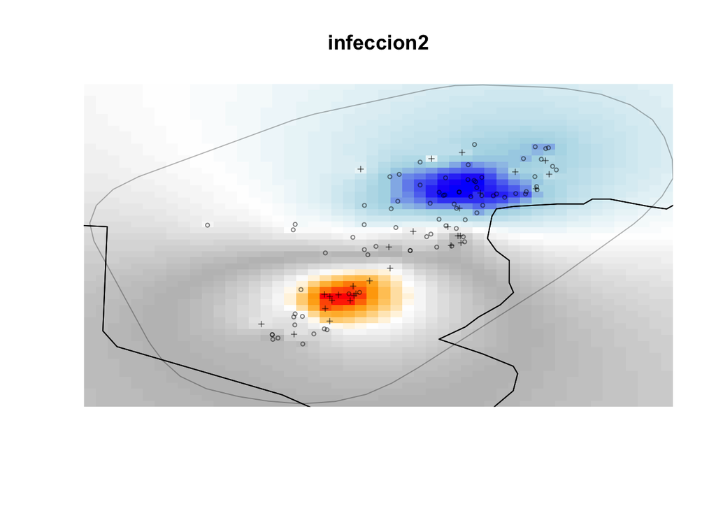

Figure 4. Map of p5 seropositives at delivery

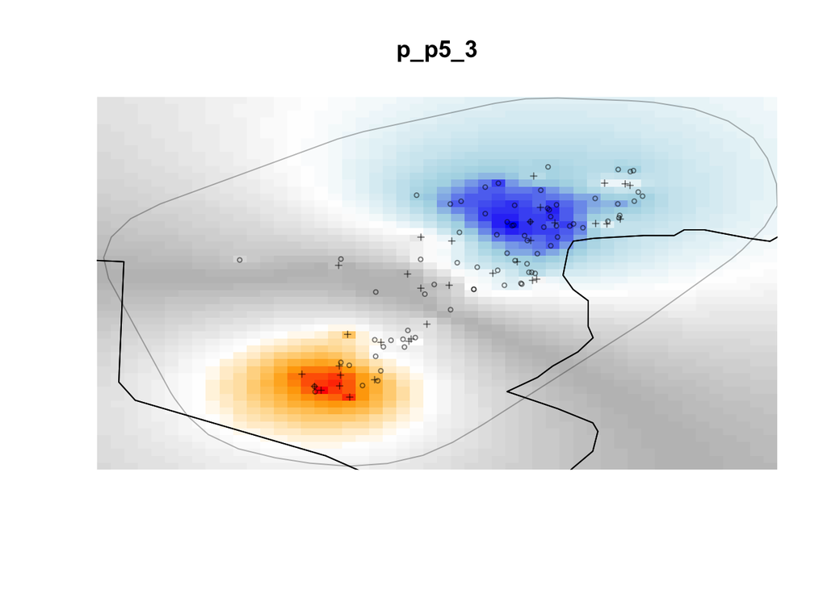

Figure 5. Map of p8 seropositives at delivery

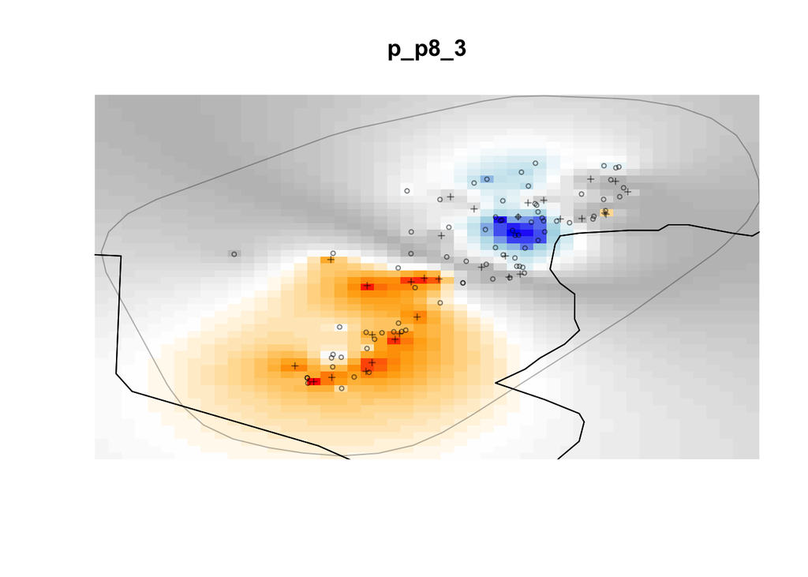

Figure 6. Map of p5+8 seropositives at delivery

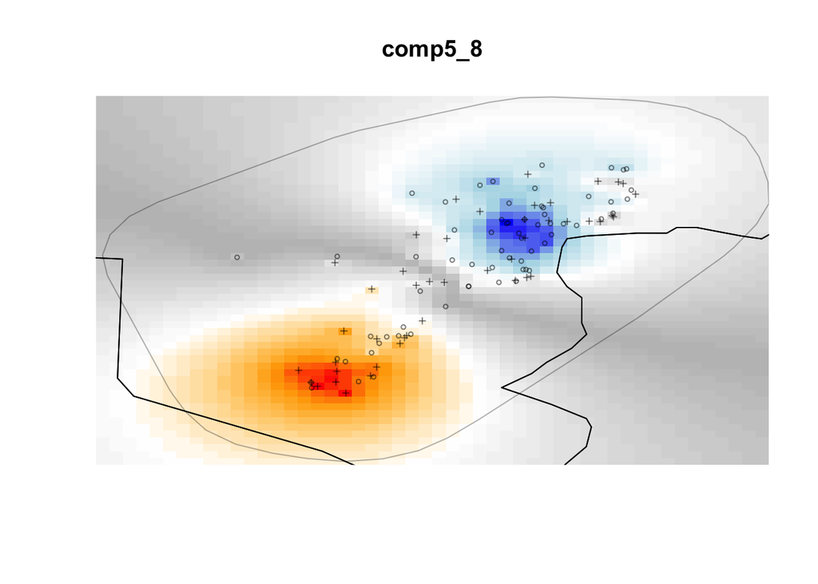

Figure 7. Map of DBL5e seropositives at delivery

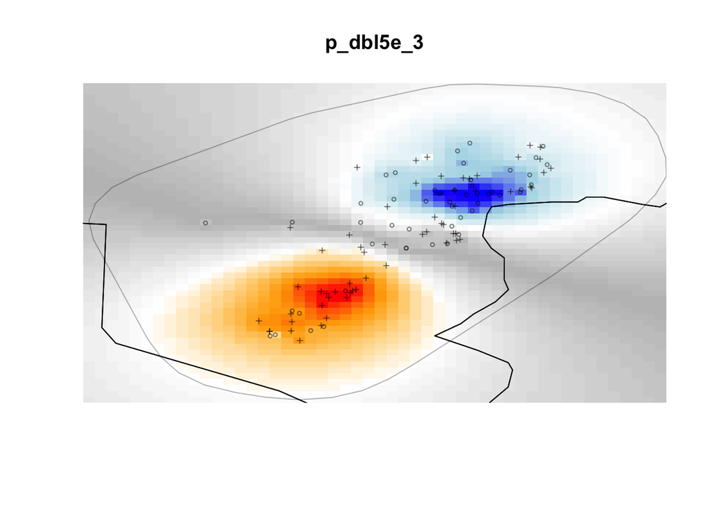

Figure 8. Map of MSP119 seropositives at delivery

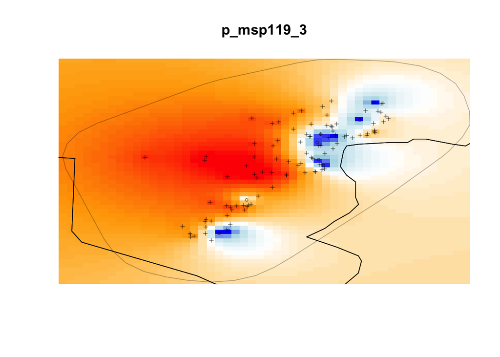

# DISCUSSION

The potential to obtain more accurate estimates of P. falciparum exposure from small sample sizes and using VAR2CSA-serology by targeting pregnant women as sentinel population makes the already promising use of serology as a key malaria surveillance tool more attractive. Surveys of pregnant women in ANC can provide a rapid, cheap and sustainable platform to assemble information on malaria risk among communities. The use of ANC platforms as sentinels does however require further validation and optimization.

Finally, programmatic research is required to assess feasibility, acceptability, and cost-effectiveness and to develop approaches to integrate this pregnancy-based sero-surveillance tool into malaria control and elimination programs and link with other surveillance strategies.

# REFERENCES

Aitken, Elizabeth H., Bernard Mbewe, Mari Luntamo, Teija Kulmala, James G. Beeson, Per Ashorn, and Stephen J. Rogerson. 2012. “Antibody to P. Falciparum in Pregnancy Varies with Intermittent Preventive Treatment Regime and Bed Net Use.” Edited by Georges Snounou. *PLoS ONE* 7 (1). Public Library of Science (PLoS): e29874. doi:10.1371/journal.pone.0029874.

Corran, Patrick H, Jackie Cook, Caroline Lynch, Heleen Leendertse, Alphaxard Manjurano, Jamie Griffin, Jonathan Cox, et al. 2008. “Dried Blood Spots as a Source of Anti-Malarial Antibodies for Epidemiological Studies.” *Malaria Journal* 7 (1). Springer Nature: 195. doi:10.1186/1475-2875-7-195.

Corran, Patrick, Paul Coleman, Eleanor Riley, and Chris Drakeley. 2007. “Serology: A Robust Indicator of Malaria Transmission Intensity?” *Trends in Parasitology* 23 (12). Elsevier BV: 575–82. doi:10.1016/j.pt.2007.08.023.

Drakeley, Chris, and Jackie Cook. 2009. “Chapter 5 Potential Contribution of Sero-Epidemiological Analysis for Monitoring Malaria Control and Elimination: Historical and Current Perspectives.” In *Advances in Parasitology Volume 69*, 299–352. Elsevier. doi:10.1016/s0065-308x(09)69005-9.

Eijk, Anna M van, Jenny Hill, Abdisalan M Noor, Robert W Snow, and Feiko O ter Kuile. 2015. “Prevalence of Malaria Infection in Pregnant Women Compared with Children for Tracking Malaria Transmission in Sub-Saharan Africa: A Systematic Review and Meta-Analysis.” *The Lancet Global Health* 3 (10). Elsevier BV: e617–e628. doi:10.1016/s2214-109x(15)00049-2.

González, Raquel, Meghna Desai, Eusebio Macete, Peter Ouma, Mwaka A. Kakolwa, Salim Abdulla, John J. Aponte, et al. 2014. “Intermittent Preventive Treatment of Malaria in Pregnancy with Mefloquine in HIV-Infected Women Receiving Cotrimoxazole Prophylaxis: A Multicenter Randomized Placebo-Controlled Trial.” Edited by Lynne Meryl Mofenson. *PLoS Medicine* 11 (9). Public Library of Science (PLoS): e1001735. doi:10.1371/journal.pmed.1001735.

González, Raquel, Ghyslain Mombo-Ngoma, Smaïla Ouédraogo, Mwaka A. Kakolwa, Salim Abdulla, Manfred Accrombessi, John J. Aponte, et al. 2014. “Intermittent Preventive Treatment of Malaria in Pregnancy with Mefloquine in HIV-Negative Women: A Multicentre Randomized Controlled Trial.” Edited by Lynne Meryl Mofenson. *PLoS Medicine* 11 (9). Public Library of Science (PLoS): e1001733. doi:10.1371/journal.pmed.1001733.

Helb, Danica A., Kevin K. A. Tetteh, Philip L. Felgner, Jeff Skinner, Alan Hubbard, Emmanuel Arinaitwe, Harriet Mayanja-Kizza, et al. 2015. “Novel Serologic Biomarkers Provide Accurate Estimates of recentPlasmodium Falciparumexposure for Individuals and Communities.” *Proceedings of the National Academy of Sciences* 112 (32). Proceedings of the National Academy of Sciences: E4438–E4447. doi:10.1073/pnas.1501705112.

Hommel, M., S. R. Elliott, V. Soma, G. Kelly, F. J. I. Fowkes, J. M. Chesson, M. F. Duffy, et al. 2010. “Evaluation of the Antigenic Diversity of Placenta-Binding Plasmodium Falciparum Variants and the Antibody Repertoire Among Pregnant Women.” *Infection and Immunity* 78 (5). American Society for Microbiology: 1963–78. doi:10.1128/iai.01365-09.

Kerkhof, Karen, Lydie Canier, Saorin Kim, Somony Heng, Tho Sochantha, Siv Sovannaroth, Inès Vigan-Womas, et al. 2015. “Implementation and Application of a Multiplex Assay to Detect Malaria-Specific Antibodies: A Promising Tool for Assessing Malaria Transmission in Southeast Asian Pre-Elimination Areas.” *Malaria Journal* 14 (1). Springer Nature. doi:10.1186/s12936-015-0868-z.

Mayor, A., E. Rovira-Vallbona, S. Machevo, Q. Bassat, R. Aguilar, L. Quinto, A. Jimenez, et al. 2011. “Parity and Placental Infection Affect Antibody Responses Against Plasmodium Falciparum During Pregnancy.” *Infection and Immunity* 79 (4). American Society for Microbiology: 1654–9. doi:10.1128/iai.01000-10.

Mayor, Alfredo, Urwashi Kumar, Azucena Bardají, Pankaj Gupta, Alfons Jiménez, Amel Hamad, Betuel Sigaúque, et al. 2013. “Improved Pregnancy Outcomes in Women Exposed to Malaria with High Antibody Levels Against Plasmodium Falciparum.” *The Journal of Infectious Diseases* 207 (11). Oxford University Press (OUP): 1664–74. doi:10.1093/infdis/jit083.

Ndam, N. G. Tuikue, A. Salanti, J.-Y. Le-Hesran, G. Cottrell, N. Fievet, L. Turner, S. Sow, J.-M. Dangou, T. Theander, and P. Deloron. 2006. “Dynamics of Anti-VAR2CSA Immunoglobulin G Response in a Cohort of Senegalese Pregnant Women.” *The Journal of Infectious Diseases* 193 (5). Oxford University Press (OUP): 713–20. doi:10.1086/500146.

Salanti, Ali, Trine Staalsoe, Thomas Lavstsen, Anja T. R. Jensen, M. P. Kordai Sowa, David E. Arnot, Lars Hviid, and Thor G. Theander. 2003. “Selective Upregulation of a Single Distinctly Structured Var Gene in Chondroitin Sulphate a-Adhering Plasmodium Falciparum Involved in Pregnancy-Associated Malaria.” *Molecular Microbiology* 49 (1). Wiley-Blackwell: 179–91. doi:10.1046/j.1365-2958.2003.03570.x.

Serra-Casas, Elisa, Clara Menéndez, Azucena Bardají, Llorenç Quintó, Carlota Dobaño, Betuel Sigauque, Alfons Jiménez, et al. 2010. “The Effect of Intermittent Preventive Treatment During Pregnancy on Malarial Antibodies Depends on HIV Status and Is Not Associated with Poor Delivery Outcomes.” *The Journal of Infectious Diseases* 201 (1). Oxford University Press (OUP): 123–31. doi:10.1086/648595.

Stewart, Laveta, Roly Gosling, Jamie Griffin, Samwel Gesase, Joseph Campo, Ramadan Hashim, Paul Masika, et al. 2009. “Rapid Assessment of Malaria Transmission Using Age-Specific Sero-Conversion Rates.” Edited by James G. Beeson. *PLoS ONE* 4 (6). Public Library of Science (PLoS): e6083. doi:10.1371/journal.pone.0006083.

WHO. 2016. “Eliminating Malaria.” WHO, Geneva, Switzerland. http://www.who.int/malaria/publications/atoz/eliminating-malaria/en/.

Willilo, Ritha A., Fabrizio Molteni, Renata Mandike, Frances E. Mugalura, Anold Mutafungwa, Adella Thadeo, Edwin Benedictor, et al. 2016. “Pregnant Women and Infants as Sentinel Populations to Monitor Prevalence of Malaria: Results of Pilot Study in Lake Zone of Tanzania.” *Malaria Journal* 15 (1). Springer Nature. doi:10.1186/s12936-016-1441-0.